[figure not shown]

#### Métodos Computacionais para Inferência Estatística

# Estimação por Máxima Verossimilhança: Distribuição exponencial

Prof. Wagner Hugo Bonat LEG/UFPR

2019

# 1 Introdução

Como vimos nos slides da aula há pelo menos três formas básicas para obtenção dos intervalos baseados na função de verossimilhança. A intuitivamente mais simples é baseada na verossimilhança relativa, isto é, o intervalo é definido pelo conjunto de valores do parâmetro que tenham uma verossimilhança não inferior a um certo percentual da verossimilhança máxima. O intervalo obtido desta forma não tem interpretação probabilística.

A segunda forma baseia-se na função *deviance*. Considerando a sua distribuição assintótica, define-se um ponto de corte nesta função e o intervalo é dado pelo conjunto dos valores do parâmetro que possuem *deviance* inferior a esse ponto de corte.

A terceira utiliza uma aproximação quadrática da função de log-verossimilhança. As últimas duas opções associam uma interpretação frequentista ao intervalo de confiança. Desta forma, os objetivos deste tutorial são: mostrar como obter os intervalos de confiança por cada uma das três abordagens, explorar as relações existentes e discutir algumas possíveis dificuldades computacionais que podem ocorrer quando trabalhamos diretamente com a função de verossimilhança relativa ou *deviance*.

# 2 Especificação do problema

Considere o caso onde amostras independentes de uma variável aleatória $Y_i$ com $i = 1, 2, \ldots,n$ cada uma tendo distribuição exponencial de parâmetro $\theta$ está disponível. Vamos denotar esta situação por $Y_i \sim {\rm Exp}(\theta)$. O objetivo é estimar o parâmetro $\theta$ e um intervalo de confiança, digamos $\hat{\theta}_L$ e $\hat{\theta}_U$ que, sob o enfoque frequentista, tenha probabilidade $1 - \alpha$ de conter $\theta$. Note que a estrutura probabilística está em $\hat{\theta}_L$ e $\hat{\theta}_U$.

# 3 Estimação via máxima verossimilhança

O primeiro passo é sempre escrever a função de verossimilhança,
$$L(\theta) = \prod_{i=1}^n \theta \exp\{-\theta y_i\} = \theta^n \exp\{-\theta \sum_{i=1}^n y_i\} =
\theta^n \exp\{-n \overline{y} \theta \}.$$

Consequentemente, a função de log-verossimilhança é
$$l(\theta) = n \log \theta - \theta \sum_{i=1}^n y_i = n \log \theta - \theta n \overline{y}.$$

Derivando a log-verossimilhança em $\theta$ chegamos a função escore
$$U(\theta) = n \theta^{-1} - n \overline{y}.$$

Para encontrar a estimativa de máxima verossimilhança basta igualar a função escore a $0$ e isolar o $\theta$ isto resulta
$$\hat{\theta} = \frac{1}{\overline{y}}.$$

A segunda derivada da função de log-verossimilhança tem um papel fundamental na construção de intervalos de confiança por aproximação quadrática da função de log-verossimilhança, uma vez que ela mede a curvatura da função no entorno do ponto de máximo.

Em termos estatísticos, trabalhamos com a informação observada ou esperada, uma vez que esta quantidade descreve o comportamento assintótico dos estimadores de máxima verossimilhança, já que sua inversa fornece a variância do estimador. Neste caso a função de log-verossimilhança é côncava e polinomial de ordem infinita. As informações esperada e observada são iguais e dependem do valor do parâmetro e na prática é necessário usar a informação estimada pela amostra.
$$I_O(\theta) = I_E(\theta) = n \theta^{-2} \;\; \mbox{ e } \;\; I_O(\hat{\theta}) = I_E(\hat{\theta}) = n \hat{\theta}^{-2}.$$

# 4 Intervalo deviance

Para encontrar o intervalo de confiança vamos começar pela função *deviance*, lembrando que de acordo com os resultados apresentados em aula a *deviance* segue uma distribuição $\chi^2$ com $p$ graus de liberdade, no exemplo $p = 1$. Desta forma o valor de $c^*$ é obtido definindo algum quantil $q_{1-\alpha}$ da distribuição qui-quadrado com $1$ grau de liberdade e $1-\alpha$ de confiança. Como exemplo, fixando $\alpha = 0,05$ toma-se o valor do quantil $c^* = 3,84$. Com isto, temos os elementos necessários para construir o intervalo de confiança baseado na função que é dado pelo conjunto de valores que obedecem:
$$\begin{eqnarray}\label{devexponencial}
D(\theta) &=& 2 [ l(\hat{\theta}) - l(\theta)] \nonumber \\
&=& 2 [ n \log \hat{\theta} - \hat{\theta} n \overline{y} - ( n \log \theta - \theta n \overline{y}) ] \nonumber \\
&=& 2n [ \log \left(\hat{\theta}/\theta \right) + \overline{y} ( \theta - \hat{\theta}) ] \leq c^*
\end{eqnarray}$$

Os limites $(\hat{\theta}_L, \hat{\theta}_U)$ são encontrados resolvendo a equação acima, mas mesmo em uma situação simples como a deste exemplo a obtenção das raízes requer a solução de uma equação não-linear que não tem solução analítica. Desta forma, algum método numérico é necessário para encontrar os limites do intervalo.

# 5 Intervalo de Wald

Uma outra opção para encontrar o intervalo de confiança é fazer uma aproximação quadrática utilizando séries de Taylor para a função $l(\theta)$ em torno do ponto $\hat{\theta}$ e usar esta aproximação no lugar da função de log-verossimilhança original para obter o intervalo de confiança. Neste caso, os limites do intervalo são as raízes de um polinômio de segundo grau e os intervalos são da forma
$$\hat{\theta} \pm z_{\frac{\alpha}{2}} \sqrt{ V(\hat{\theta})},$$
o que corresponde a usar a distribuição assintótica do EMV.

Para a distribuição exponencial, temos que a $V(\hat{\theta}) = I_O^{-1}(\hat{\theta}) = \hat{\theta}^2/n$, logo o intervalo de confiança é dado por
$$\hat{\theta}_L = \hat{\theta} - z_{\frac{\alpha}{2}} \hat{\theta}/\sqrt{n}
\quad \text{e} \quad \hat{\theta}_U = \hat{\theta} + z_{\frac{\alpha}{2}} \hat{\theta}/\sqrt{n} .$$

Aqui a construção do intervalo de confiança fica bastante facilitada. Conhecendo o valor de $z_{\frac{\alpha}{2}}$ o intervalo se resume a uma conta simples, ou seja, não é necessário utilizar métodos numéricos para obtenção dos limites do intervalo. Como a distribuição amostral de $\hat{\theta}$ é assintóticamente gaussiana podemos escolher o valor de $z_{\frac{\alpha}{2}}$ como o quantil da distribuição normal, com $(1-\alpha)$ 100% de confiança, escolhendo $\alpha = 0,05$, temos aproximadamente que $z_{\frac{\alpha}{2}} = 1,96$. No caso de $d=1$ o quantil da distribuição $\chi^2_{(1)}$ é o quadrado de um score $z$ da distribuição normal e o método também corresponde a obter o intervalo como na função *deviance* porém utilizando a sua aproximação quadrática dada por:
$$D(\theta) \approx n \left(\frac{\theta-\hat{\theta}}{\hat{\theta}} \right)^2.$$
Desta forma as raízes que definem os limites dos intervalos equivalentes aos anteriores são:
$$\left(\hat{\theta}_L \approx \hat{\theta} (1-\sqrt{c^*/n}) \;\; , \;\;
\hat{\theta}_U \approx \hat{\theta} (1+\sqrt{c^*/n})\right) .$$

# 6 Intervalo baseado em perda relativa

A última opção que vamos considerar é a construção do intervalo definindo um valor limite para a verossimilhança relativa. Um intervalo baseado em verossimilhança relativa é da forma $LR(\theta) = \frac{L(\theta)}{L(\hat{\theta})} \ge r$, onde $r$ representa um percentual do máximo da função de verossimilhança, para o qual admite-se ainda obter uma estimativa aceitável de $\theta$. Por exemplo, definindo $r=0.25$, o intervalo é definido pelo valores que apresentam uma verosimilhança que seja ao menos 25% da máxima para o conjunto de dados. Para escolher um valor de $r$ comparável com o escolhido para a *deviance*, note o seguinte:
$$\begin{eqnarray*}
\frac{L(\theta)}{L(\hat{\theta})} &\ge& r \\
\log \left[ \frac{L(\theta)}{L(\hat{\theta})} \right] &\ge& \log r \\
-2[ l(\theta) - l(\hat{\theta})] &\ge& -2 \cdot \log r\\
3,84 & \ge& -2 \cdot \log r \\
r &\approx& 0,146
\end{eqnarray*}$$

A Tabela abaixo mostra a relação entre alguns valores de corte da verossimilhança relativa e os valores correspondentes em log-verossimilhança e em deviance. Na prática, os níveis de confiança são aproximados e válidos apenas assintóticamente.

[output not shown]

Com isso, podemos observar que usar a verossimilhança relativa ou a *deviance* são formas equivalentes de construir o intervalo de confiança. A diferença está na interpretação que é associada aos intervalos. A vantagem em usar a *deviance* é que conhecemos a sua distribuição assintótica o que permite a construção de intervalos de confiança com a desejada estrutura probabilística. Da mesma forma que para a *deviance* a obtenção do intervalo pela verossimilhança relativa também requer resolver uma equação não-linear utilizando algum método numérico para encontrar as raízes da equação $LR(\theta) \ge r$.

# 7 Implementação computacional

Para ilustrar a construção dos intervalos de confiança, vamos considerar uma amostra de tamanho $n = 20$ gerada de uma distribuição exponencial com parâmetro $\theta = 1$.

```r
set.seed(123)
y <- rexp(20, rate=1)
```

Vamos escrever funções em **R** para avaliar as funções de verossimilhança e log-verossimilhança. Baseado nestas funções podemos avaliar a verossimilhança relativa e a *deviance*. Por fim, criamos uma função para avaliar a *deviance* aproximada usando a aproximação em série de Taylor.

```r
grid.theta <- seq(0.68,2,l=100)
## Verossimilhança
Lik <- function(theta,y){
  Lt <- prod(dexp(y,rate=theta,log=FALSE))
  return(Lt)
}
L.theta <- sapply(grid.theta, Lik, y=y)

## Verossimilhança relativa
LR.theta <- L.theta/Lik(theta=1/mean(y),y=y)

## Log-verossimilhança
ll <- function(theta,y){
  llt <- sum(dexp(y,rate=theta,log=TRUE))
  return(llt)
}
ll.theta <- sapply(grid.theta, ll, y=y)

## Deviance
dev.theta <- 2*(ll(1/mean(y),y=y)-ll.theta)

## Deviance aproximada
dev.aprox <- function(theta,theta.hat,y){
  dev <- (theta - theta.hat)^2*(length(y)/(theta.hat^2))
  return(dev)
}
devA.theta <- sapply(grid.theta, dev.aprox, theta.hat = 1/mean(y), y=y)
```

Vamos plotar alguns gráficos para ver o comportamento das funções.

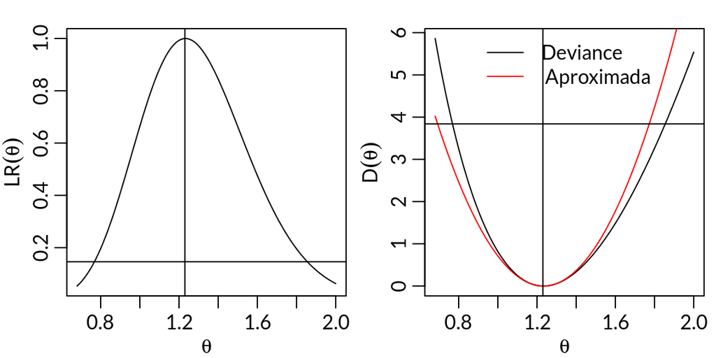

```r
theta.est <- round(1/mean(y), dig=2)
par(mfrow = c(1,2), mar=c(2.6, 2.8, 1.2, 0.5), mgp = c(1.6, 0.6, 0))
plot(LR.theta ~ grid.theta,type="l",ylab=expression(LR(theta)),xlab=expression(theta))
abline(h=0.146)
abline(v = theta.est)
plot(dev.theta ~ grid.theta,type="l",ylab=expression(D(theta)),xlab=expression(theta))
lines(devA.theta ~ grid.theta,type="l",col="red",lty=1)
abline(h=3.84)
abline(v = theta.est)
legend("top",legend=c("Deviance"," Aproximada"),col=c("black","red"), lty=c(1,1), bty="n")
```

Como é possível ver na Figura acima a função *deviance* é razoavelmente aproximada por uma forma quadrática mas esta aproximação vai depender do valor do parâmetro e do tamanho da amostra. Para obter os limites inferior e superior do intervalo de confiança pela aproximação quadrática temos:
$$\hat{\theta}_L = \hat{\theta} - z_{\frac{\alpha}{2}} \sqrt{\hat{\theta}^2/n} \quad \text{e} \quad \hat{\theta}_U = \hat{\theta} + z_{\frac{\alpha}{2}} \sqrt{\hat{\theta}^2/n}$$
Para a amostra simulada utilizada para gerar os gráficos temos os seguintes valores:
$$\hat{\theta}_L = 1.23(1 - 1.96 \sqrt{1/20}) \quad \text{e} \quad
\hat{\theta}_U = 1.23(1 + 1.96 \sqrt{1/20}) ,$$
que resulta no seguinte intervalo de confiança:
$$\hat{\theta}_L = 0.6909; \quad \hat{\theta}_U = 1.7690.$$

Usando a função *deviance* precisamos resolver uma equação não-linear. Em **R** podemos facilmente resolver este problema usando as funções do pacote **rootSolve**. O algoritmo implementado na função **uniroot()** é uma variação do método de Brent que veremos na aula sobre métodos de otimização. De forma geral é um algoritmo de confinamento e por isso precisamos especificar os limites inferior e superior de busca. Lembrando que nos limites a função deve ter sinais trocados.

O primeiro passo é escrever a função *deviance*,

```r
ICdevExp <- function(theta, theta.hat, y, nivel=0.95){
  n <- length(y)
  dv <- 2*n*( log( theta.hat/theta) + mean(y)*(theta- theta.hat))
  return(dv - qchisq(nivel,df=1))
}
```

Uma vez com a função escrita podemos encontrar suas raízes usando a função **uniroot.all()**.

```r
require(rootSolve)
# Loading required package: rootSolve
uniroot.all(ICdevExp, interval=c(0,10), theta.hat=1/mean(y),y=y)
# [1] 0.7684028 1.8547415
```

A Figura acima mostra o intervalo aproximado pela forma quadrática com um deslocamento para a esquerda quando comparado com o intervalo baseado na função *deviance*. É importante ter bastante cuidado na interpretação destes intervalos.

De acordo com a interpretação frequentista de probabilidade, se realizarmos o mesmo experimento um grande número de vezes e em cada um destes experimentos calcularmos o respectivo intervalo de confiança esperamos que em $(1-\alpha)$ 100% dos intervalos construídos contenham o verdadeiro valor do parâmetro. Isto pode ser ilustrado com o seguinte estudo de simulação em que geramos 100 amostras cada uma de tamanho $n=70$, com valor do parâmetro igual a 1. Ao final do experimento verificamos a taxa de cobertura, isto é, construímos o intervalo de confiança e ao final verificamos a proporção dos intervalos que contém o verdadeiro valor do parâmetro.

```r
THETA <- 1
set.seed(12)
ic <- matrix(NA, ncol=2, nrow=100)
for(i in 1:100){
  y <- rexp(70, rate=THETA)
  est <- 1/mean(y)
  ic[i,] <- uniroot.all(ICdevExp, int=c(0,5), theta.hat=est, y=y)
}
mean(apply(ic, 1, function(x) (x[1] < THETA & x[2] > THETA)))
# [1] 0.95
```

No código acima simulamos a cada passo do laço **for()** uma nova realização da variável aleatória $Y$, com esta realização calculamos a estimativa de máxima verossimilhança e o seu respectivo intervalo de confiança baseado na *deviance* e guardamos o resultado em um objeto chamado $ic$. De acordo com a interpretação frequentista dos $100$ intervalos de confiança que calculamos esperamos que $95$ deles contenham o verdadeiro valor do parâmetro neste caso $\theta = 1$.

O gráfico apresentado abaixo ilustra os resultados. Neste caso, conforme esperado, temos exatamente que $5$ dos intervalos não contem o valor verdadeiro do parâmetro. É claro que por se tratar de um exemplo de simulação variações podem ocorrer.

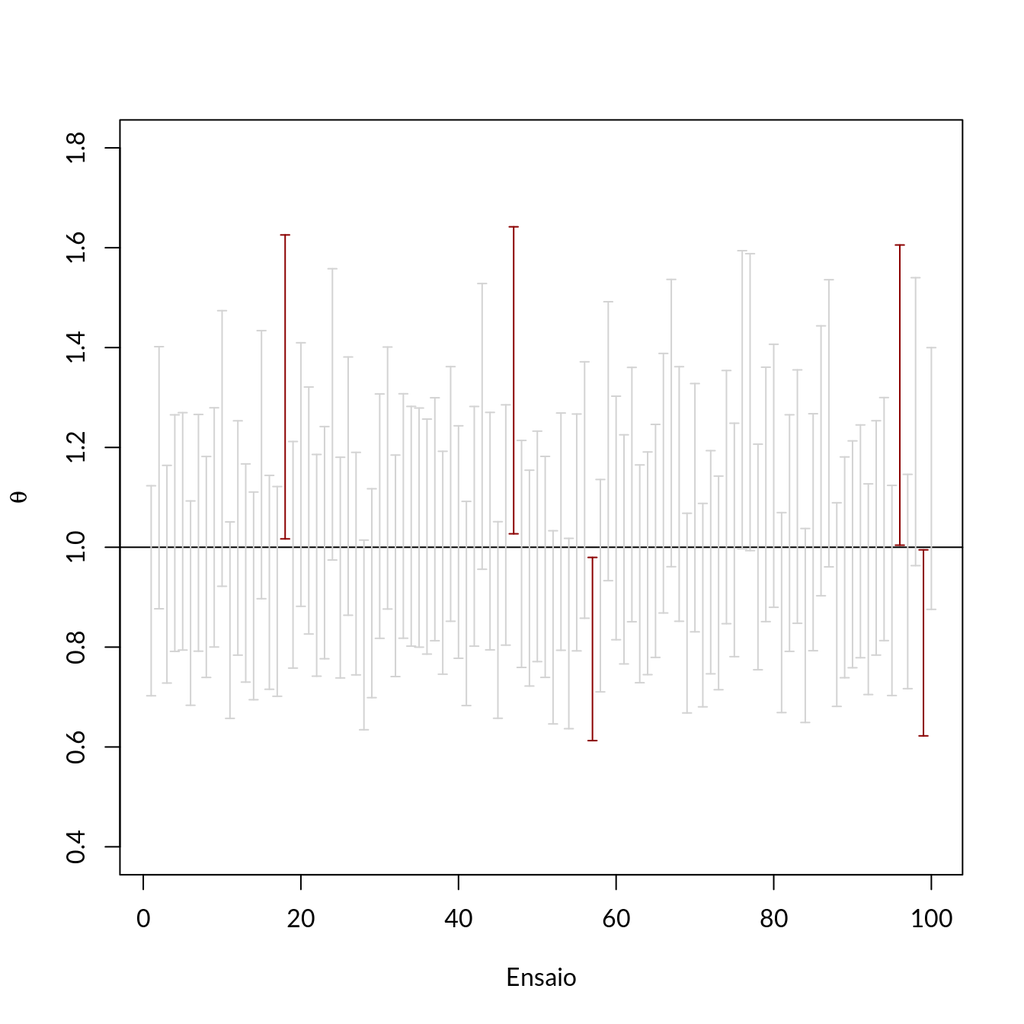

```r
plot(c(0.4,1.8)~c(1,100),type="n",ylab=expression(theta),xlab="Ensaio")
abline(h=1)
for(i in 1:100){
arrows(c(i),ic[i,1],c(i),ic[i,2],code=3,angle=90,length=0.03,
       col=ifelse(ic[i,1] > 1 | ic[i,2] < 1, "darkred","lightgray"))
# ,      lty=ifelse(ic[i,1] > 1 | ic[i,2] < 1, 1, 2))
}
```

A taxa de cobertura de um intervalo é a proporção de vezes em que os intervalos contêm o verdadeiro valor do parâmetro sobre o total de ensaios simulados. Neste caso obtivemos exatamente $95/100$, ou seja, a taxa de cobertura é de $95$% igual ao nível nominal especificado para este intervalo. A taxa de cobertura é uma forma muito utilizada para avaliar e comparar métodos de construção de intervalos de confiança.

[output not shown]